# P8105 Homework 3

Chenxin Zhang

10/10/2020

## Probalem 1

This dataset contains 1384617 rows and 15 columns.

Observations are the level of items in orders by user. There are user / order variables – user ID, order ID, order day, and order hour. There are also item variables – name, aisle, department, and some numeric codes.

How many aisles, and which are most items from?

```
## # A tibble: 134 x 2
##    aisle                              n
##    <chr>                          <int>
##  1 fresh vegetables              150609
##  2 fresh fruits                  150473
##  3 packaged vegetables fruits     78493
##  4 yogurt                         55240
##  5 packaged cheese                41699
##  6 water seltzer sparkling water  36617
##  7 milk                           32644
##  8 chips pretzels                 31269
##  9 soy lactosefree                26240
## 10 bread                          23635
## # ... with 124 more rows
```

Let’s make a plot

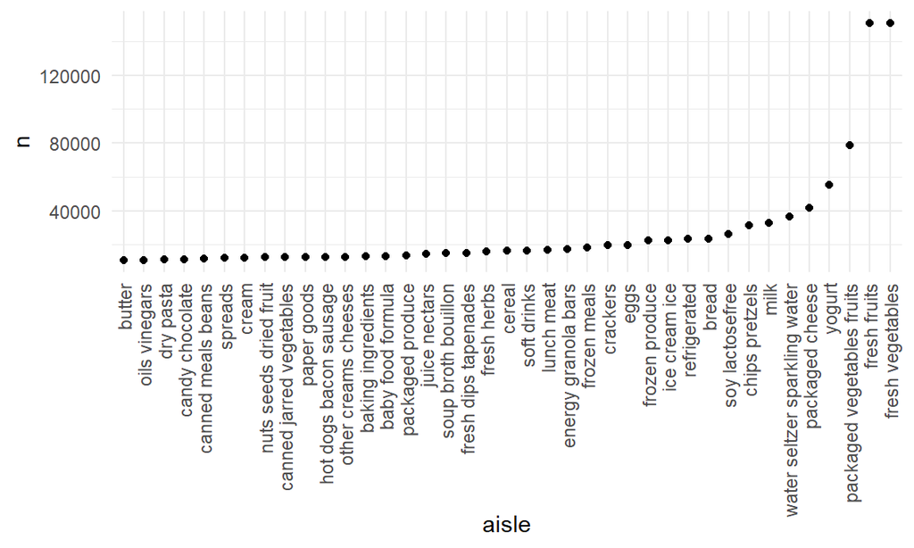

Let’s make a table!!

| aisle | product_name | n | rank |
| --- | --- | --- | --- |
| baking ingredients | Light Brown Sugar | 499 | 1 |
| baking ingredients | Pure Baking Soda | 387 | 2 |
| baking ingredients | Cane Sugar | 336 | 3 |
| dog food care | Snack Sticks Chicken & Rice Recipe Dog Treats | 30 | 1 |
| dog food care | Organix Chicken & Brown Rice Recipe | 28 | 2 |
| dog food care | Small Dog Biscuits | 26 | 3 |
| packaged vegetables fruits | Organic Baby Spinach | 9784 | 1 |
| packaged vegetables fruits | Organic Raspberries | 5546 | 2 |
| packaged vegetables fruits | Organic Blueberries | 4966 | 3 |

Apples vs ice cream..

```
## # A tibble: 2 x 8
## # Groups:   product_name [2]
##   product_name       `0`   `1`   `2`   `3`   `4`   `5`   `6`
##   <chr>            <dbl> <dbl> <dbl> <dbl> <dbl> <dbl> <dbl>
## 1 Coffee Ice Cream  13.8  14.3  15.4  15.3  15.2  12.3  13.8
## 2 Pink Lady Apples  13.4  11.4  11.7  14.2  11.6  12.8  11.9
```

## Probalem 2

#### 2.1 Load, tidy, and otherwise wrangle the data

```
## # A tibble: 50,400 x 6
##    week  day_id day    minute ac_counts weekday_weekend
##    <fct> <fct>  <fct>   <int>     <dbl> <fct>
##  1 1     1      Friday      1      88.4 weekday
##  2 1     1      Friday      2      82.2 weekday
##  3 1     1      Friday      3      64.4 weekday
##  4 1     1      Friday      4      70.0 weekday
##  5 1     1      Friday      5      75.0 weekday
##  6 1     1      Friday      6      66.3 weekday
##  7 1     1      Friday      7      53.8 weekday
##  8 1     1      Friday      8      47.8 weekday
##  9 1     1      Friday      9      55.5 weekday
## 10 1     1      Friday     10      43.0 weekday
## # ... with 50,390 more rows
```

- This dataset includes 50400 rows and 6. It is consist of variabels：week, day_id, day, minute, ac_counts, weekday_weekend.

#### 2.2 the total activity over the day

| week | Monday | Tuesday | Wednesday | Thursday | Friday | Saturday | Sunday | total_week |
| --- | --- | --- | --- | --- | --- | --- | --- | --- |
| 1 | 78828.07 | 307094.2 | 340115 | 355923.6 | 480542.6 | 376254 | 631105 | 196039594401 |
| 2 | 295431.00 | 423245.0 | 440962 | 474048.0 | 568839.0 | 607175 | 422018 | 45410217006 |
| 3 | 685910.00 | 381507.0 | 468869 | 371230.0 | 467420.0 | 382928 | 467052 | 126168055179 |
| 4 | 409450.00 | 319568.0 | 434460 | 340291.0 | 154049.0 | 1440 | 260617 | 49864375939 |
| 5 | 389080.00 | 367824.0 | 445366 | 549658.0 | 620860.0 | 1440 | 138421 | 66111700330 |

#### 2.3 single-panel plot

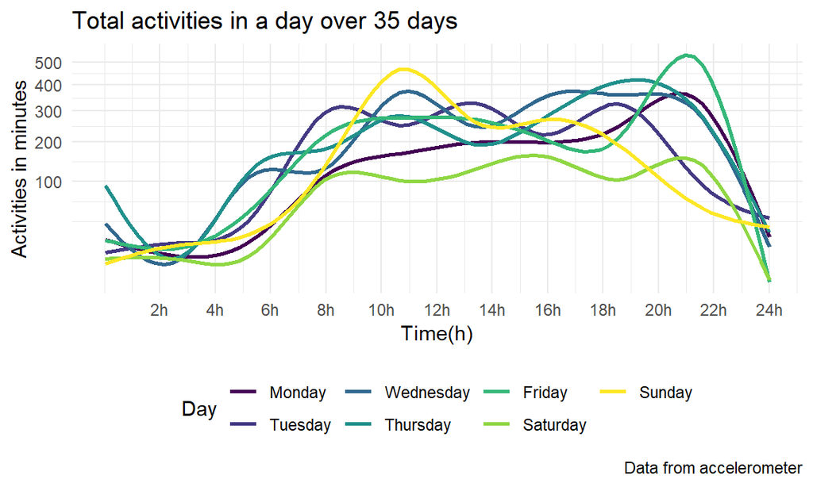

- As is shown in the graph, the men usually does activity frequently from 8am to 9pm in weekdays. During weekend, he has less activity time on Saturday, while much activity time in Sunday morning.

## Problem 3

#### 3.1 Data cleaning

Data summary

| Name | ny_noaa_df |
| --- | --- |
| Number of rows | 2595176 |
| Number of columns | 9 |
| _______________________ |  |
| Column type frequency: |  |
| character | 1 |
| factor | 3 |
| numeric | 5 |
| ________________________ |  |
| Group variables | None |

**Variable type: character**

| skim_variable | n_missing | complete_rate | min | max | empty | n_unique | whitespace |
| --- | --- | --- | --- | --- | --- | --- | --- |
| id | 0 | 1 | 11 | 11 | 0 | 747 | 0 |

**Variable type: factor**

| skim_variable | n_missing | complete_rate | ordered | n_unique | top_counts |
| --- | --- | --- | --- | --- | --- |
| year | 0 | 1 | FALSE | 30 | 201: 159671, 200: 148721, 200: 122665, 200: 93249 |
| month | 0 | 1 | FALSE | 12 | 10: 224471, 12: 223603, 07: 220348, 08: 220100 |
| day | 0 | 1 | FALSE | 31 | 01: 85258, 02: 85258, 03: 85258, 04: 85258 |

**Variable type: numeric**

| skim_variable | n_missing | complete_rate | mean | sd | p0 | p25 | p50 | p75 | p100 |
| --- | --- | --- | --- | --- | --- | --- | --- | --- | --- |
| prcp | 145838 | 0.94 | 2.98 | 7.82 | 0.0 | 0.0 | 0.0 | 2.3 | 2286 |
| snow | 381221 | 0.85 | 4.99 | 27.22 | 0.0 | 0.0 | 0.0 | 0.0 | 10160 |
| snwd | 591786 | 0.77 | 37.31 | 113.54 | 0.0 | 0.0 | 0.0 | 0.0 | 9195 |
| tmax | 1134358 | 0.56 | 13.98 | 11.14 | -38.9 | 5.0 | 15.0 | 23.3 | 60 |
| tmin | 1134420 | 0.56 | 3.03 | 10.40 | -59.4 | -3.9 | 3.3 | 11.1 | 60 |

```
## # A tibble: 281 x 4
##     snow na.rm       n  rank
##    <dbl> <lgl>   <int> <int>
##  1     0 TRUE  2008509     1
##  2     3 TRUE     8790    10
##  3     5 TRUE     9748     8
##  4     8 TRUE     9962     7
##  5    10 TRUE     5106    12
##  6    13 TRUE    23095     4
##  7    15 TRUE     3672    16
##  8    18 TRUE     3226    17
##  9    20 TRUE     4797    13
## 10    23 TRUE     1959    24
## # ... with 271 more rows
```

- The dataset is consist of 2595176 rows and 9 columns. It contains variables: id, year, month, day, prcp, snow, snwd, tmax, tmin. For snowfall, the most commonly observed value is 0. As is shown in the snow_df, there are 2,008,509 out of 2,595,176 days without snow, which rank 1.

#### 3.2 Average max temperature in January and in July

*January outliers

| year | month | id | avg_tmax |
| --- | --- | --- | --- |
| 1982 | 01 | USC00301723 | -13.4 |
| 1994 | 01 | USC00304996 | -10.6 |
| 1994 | 01 | USW00094725 | -10.2 |
| 1998 | 01 | USC00303464 | 10.2 |
| 2004 | 01 | USC00306957 | -10.8 |
| 2004 | 01 | USW00094725 | -10.4 |
| 2004 | 01 | USW00094740 | -10.4 |
| 2005 | 01 | USC00305925 | -12.2 |

*July outliers

| year | month | id | avg_tmax |
| --- | --- | --- | --- |
| 1984 | 07 | USC00308946 | 19.1 |
| 1988 | 07 | USC00308962 | 14.0 |
| 2000 | 07 | USC00306957 | 19.8 |
| 2000 | 07 | USC00308248 | 19.9 |
| 2004 | 07 | USC00302454 | 18.3 |
| 2007 | 07 | USC00309389 | 19.2 |
| 2010 | 07 | USC00305377 | 33.6 |

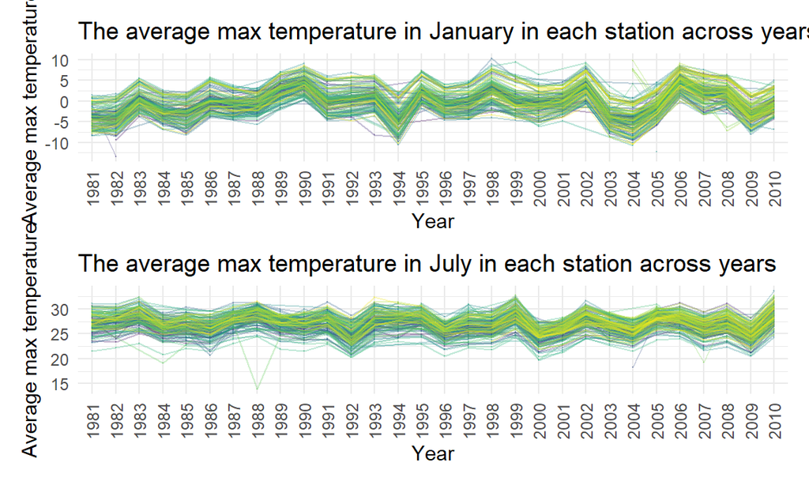

```r
Jan_avg_temp/jul_avg_temp
```

#### 3.3

*plot showing tmax vs tmin for the full dataset* plot showing the distribution of snowfall values greater than 0 and less than 100 separately by year

*two-panel plot

[figure not shown]

```r
(temp_df / snowfall_df) + plot_layout(widths = 10, heights = 20)
```

- The temp_df shows that the maximum temperatures over years have a larger range between the Q1 to Q3 than the minimum temperature, according to the width of the box. However, the minimum temperatures over years have larger range from Q1 to Q4, as they have more outliers.
- The snowfall_df shows the values of snowfall concentrate on 0-25mm, 50mm, 75mm. The fluctuation of snowfall over years are stable.